# Applied Multivariate Analysis HW1

[figure not shown]

[figure not shown]

[figure not shown]

本次作業使用 R 套件 ggplot2 中內建資料 *mpg*，此數據為 EPA 在 https://fueleconomy.gov/ 上所提供關於燃油經濟性數據的一個子集，包含了 1999 年和 2008 年發布的新版本車型，共 234 筆觀測值，11 個變數。

### Variables

| **變數名稱** | **變數類型** | **變數解釋** |  |  |  |  |  |  |  |
| --- | --- | --- | --- | --- | --- | --- | --- | --- | --- |
| manufacturer | qualitative (nominal) | 製造商名稱 |  |  |  |  |  |  |  |
| model | qualitative (nominal) | 車型名稱 |  |  |  |  |  |  |  |
| displ | quantitative (continuous) | 發電機排量 (engine displacement) 單位：升 |  |  |  |  |  |  |  |
| year | quantitative (discrete) | 製造年份 (1999, 2008) |  |  |  |  |  |  |  |
| cyl | quantitative (discrete) | 汽缸數量 |  |  |  |  |  |  |  |
| trans | qualitative (nominal) | 傳輸類型 |  |  |  |  |  |  |  |
| drv | qualitative (nominal) | 傳動系統類型 (f=front-wheel drive, r=rear-wheel drive, 4=4-wheel drive) |  |  |  |  |  |  |  |
| cty | quantitative (continuous) | 每加侖城市英哩數 |  |  |  |  |  |  |  |
| hwy | quantitative (continuous) | 每加侖公路英哩數 |  |  |  |  |  |  |  |
| fl | qualitative (nominal) | 汽油種類 |  |  |  |  |  |  |  |
| class | qualitative (nominal) | 汽車的類型 |  |  |  |  |  |  |  |

### Chart A (Scatter plot)

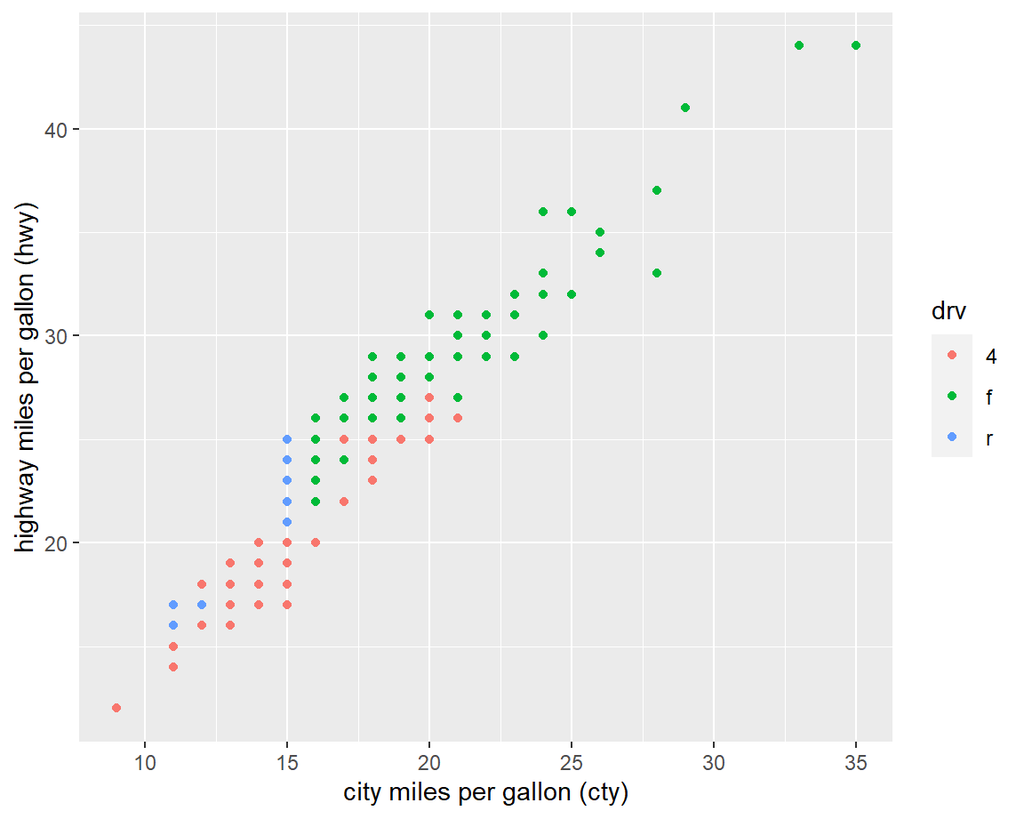

### Interpretation A

1. *cty* 和 *hwy* 呈現明顯正相關，且相同汽車下 *hwy* 數值皆大於 *cty*。
2. 四輪驅動的汽車 *cty* 和 *hwy* 分佈皆偏低，其次為後輪驅動，前輪驅動分佈則偏高。

### Chart B (Box plot)

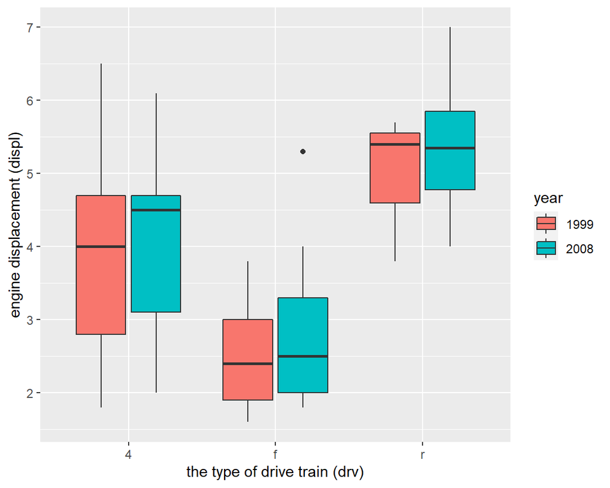

### Interpretation B

1. 2008 年生產的汽車發電機排放量分佈約略大於 1999 年生產的，但圖形顯示上並不是太顯著。
2. 三種傳動系統類型的汽車中，後輪驅動的汽車發電機排放量最大，其次為四輪驅動，前輪驅動則最低。

### Chart C (Interaction plot)

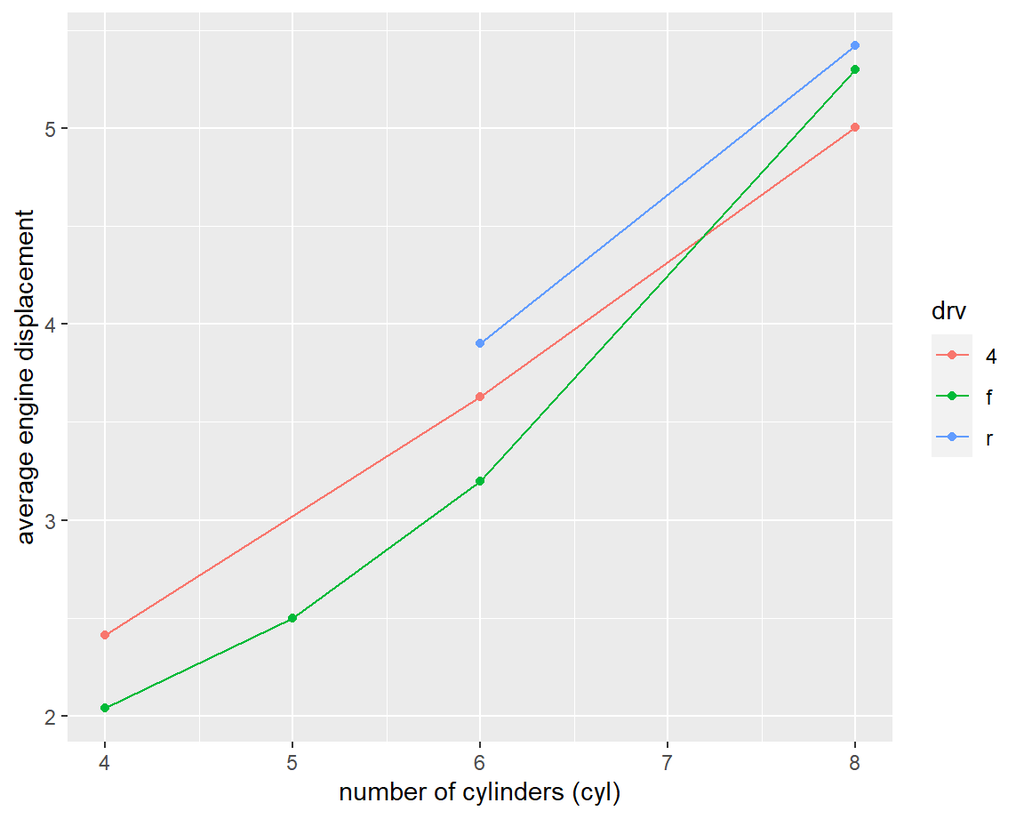

### Interpretation C

1. 隨著汽缸數的增加，三種傳動系統類型的汽車的發電機排放量平均值皆隨之上升。
2. 四輪驅動和後輪驅動所代表的折線大致呈現平行，但前輪驅動的折線則和他們不平行，甚至有相交，故可以推測變數*cyl* 和 *drv* 之間有著交互作用。